# Kernel Convolution

# Notes and things to add

#### Why would we want to use this model?

- can create valid positive definite covariance structures with desired properties
- non-stationary
- directional covariances for stream flow
- fast to compute
- Models similar to kernel convolution
- dimension reduction techniques like fixed rank kriging and predictive process

```r
## Set seed and load libraries/functions
set.seed(11)
library(nlme)
library(lme4)
library(myFunctions)
library(mvtnorm)
library(maps)
library(fields)
library(MASS)
```

# Higdon model

The generic mixed model representation for spatially correlated random variables can be written as $\mathbf{y}(\mathbf{s}) = \mathbf{X}(\mathbf{s}) \boldsymbol{\beta} + \boldsymbol{\eta}(\mathbf{s}) + \boldsymbol{\epsilon},$ where $\mathbf{y}(\mathbf{s})$ represents data observed at a vector of spatial locations $\mathbf{s} \in \mathbf{\mathcal{S}}$.

The above model can be re-written as $\mathbf{y}(\mathbf{s}) = \mathbf{X}(\mathbf{s}) \boldsymbol{\beta} + \mathbf{K} \boldsymbol{\alpha} + \boldsymbol{\epsilon},$ where the spatially correlated random effect $\boldsymbol{\eta}(\mathbf{s})$ is replaced by the matrix $\mathbf{K}$ where the $ij^{th}$ elements of $\mathbf{K}$ are the normal density $\boldsymbol{\Phi}(\mathbf{u}_i - \mathbf{s}_j)$ evaluated at the distance between knot location $\mathbf{u}_i$ and observation location $\mathbf{s}_j$ for a set of knots $\mathbf{u} \in \mathbf{\mathcal{U}}$. The matrix $\mathbf{K}$ is multiplied by a mean zero white noise Gaussian random effect $\boldsymbol{\alpha}$, forming a discrete approximation to the kernel convolution process.

### Higdon model fit

[figure not shown]

```r
# a fake dataset to make the bumps
n <- 30
m <- 7
s_full <- seq(1, 10, length = 1000)
s <- seq(1, 10, length = n)
# create the data
e1 <- rnorm(n, sd=0.1)
e2 <- cos(s / 10 * 2 * pi * 4) * 0.2
e2_full <- cos(s_full / 10 * 2 * pi * 4) * 0.2
y <- sin(s / 10 * 2 * pi) + e1 + e2
z_full <- sin(s_full / 10 * 2 * pi) + e2_full
# plot(y ~ s, type = 'l')
# lines(z_full ~ s_full, col = 'green')
# location of support points
w <- seq(1 - 2, 10+2, length = m)
# width of kernel
sdkern <- 2
# create the matrix K
K <- matrix(NA, ncol=m, nrow=n)
for(i in 1:m){
  K[, i] <- dnorm(s, mean = w[i], sd = sdkern)
}
# create a dataframe to hold the data
df1 <- data.frame(y=y, K=K, sub=1)
df1$sub <- as.factor(df1$sub)
# now fit a mixed model using lme
# a1 <- lme(fixed=y ~ 1, random=pdIdent(~ K - 1), data=df1, na.action=na.omit)
a1 <- lme(fixed=y ~ 1, random=list(sub = pdIdent(~ K - 1)), data=df1, na.action=na.omit)
# lmer(y ~ 1 + (K - 1  ), data=df1)
# obtain and plot the fitted values
a1p <- as.vector(predict(a1, df1))
# lines(s, a1p, lty = 1, col = 'red')

# now a multiscale version
m1 <- c(7, 14, 28)  # number of knot upport points at each scale
w <- list(NULL)  # list to hold the knot locations
# make support locations w
for(i in 1:3){
  w[[i]] <- seq(1-2, 10+2, length = m1[i])
}
sdkern <- c(2, 1, 0.5) # kernel width by scale
# generate K matrices for each scale
K1 <- matrix(NA, ncol=m1[1], nrow=n)
for(i in 1:m1[1]){
  K1[, i] <- dnorm(s, mean=w[[1]][i], sd=sdkern[1])
}
K2 <- matrix(NA, ncol=m1[2], nrow=n)
for(i in 1:m1[2]){
  K2[, i] <- dnorm(s, mean=w[[2]][i], sd=sdkern[2])
}
K3 <- matrix(NA, ncol=m1[3], nrow=n)
for(i in 1:m1[3]){
  K3[, i] <- dnorm(s, mean=w[[3]][i], sd=sdkern[3])
}
# create dataframe df2
df2 <- data.frame(y=y, K1=K1, K2=K2, K3=K3, sub=1)
# fit mixed effects model
a2 <- lme(fixed=y ~ 1, random=list(sub = pdIdent(~ K1 - 1), sub = pdIdent(~ K2 - 1), sub = pdIdent(~ K3 - 1)), data=df2, na.action=na.omit)
# get predictions
a2p <- as.vector(predict(a2, df2))
# plots
plot(s, y, type = 'n', main = "Higdon Example")
points(s, y)
lines(s, a1p, col = 'red')
lines(s, a2p, col = 'blue')
lines(s_full, z_full, col = 'darkgreen')
legend(x="topright", legend=c("truth", "one scale", "multiscale"), col=c("red", "blue", "darkgreen"), lty=1)
rug(s)
```

## Simulate some data from a traditional geostatistical model

We simulate data from the traditional geostatistical model

$\mathbf{y} = \mathbf{X} \boldsymbol{\beta} + \boldsymbol{\eta} + \boldsymbol{\epsilon}$

where the spatially correlated random error is given by $\boldsymbol{\eta} \sim \mbox{N}(\mathbf{0}, \sigma^2_{\eta} \mathbf{R}(\boldsymbol{\theta}))$ for a Mátern class correlation function $\mathbf{R}(\boldsymbol{\theta})$ and the independent error is $\boldsymbol{\epsilon} \sim \mbox{N}(\mathbf{0}, \sigma^2_{\epsilon} \mathbf{I})$. For our simulation we use an Exponential correlation where the $ij^{th}$ element of the covariance matrix $\mathbf{R}_{ij}(\mathbf{\theta}) = \exp{ \{ - \phi * d_{ij}\} }$ where $d_{ij}$ is the Euclidean distance between locations $i$ and $j$.

For this example we allow for $\mathbf{\beta}$ to have an intercept $\beta_0$, regression parameter $\beta_1$ uncorrelated with the spatial random effect, and a regression parameter $\beta_2$ highly correlated with the spatial random effect.

## Next, let’s explore the model using traditional kernel convolution spatial regression

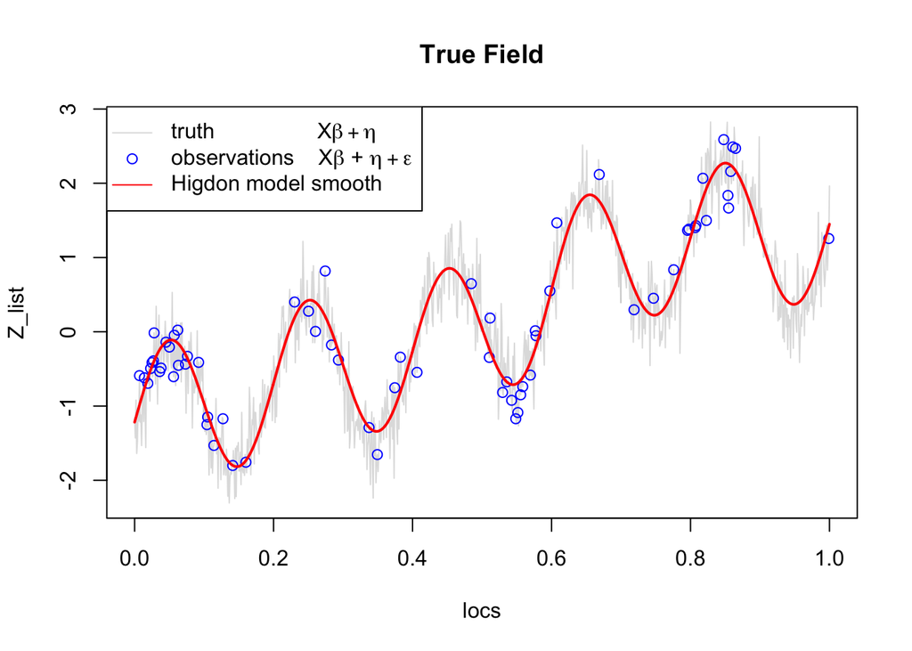

#### Examine model output

```r
library(xtable)
results=data.frame(rbind(c(beta, s2_e), c(example_model$coefficients$fixed, example_model$sigma^2)), row.names = c("Truth", "Estimate"))
names(results) = c("beta_1", "beta_2", "beta_3", "sigma^2")
# tab=xtable(results)
print(xtable(results), type="html")
```

|  | beta_1 | beta_2 | beta_3 | sigma^2 |
| --- | --- | --- | --- | --- |
| Truth | 0.00 | 1.00 | 2.00 | 0.10 |
| Estimate | -1.20 | 0.98 | 2.77 | 0.09 |

```r
library(pander)
 pandoc.table(results, style="rmarkdown")
```

## Now let’s examine a hierarchical Bayesian model for kernel convolution.

### Data model

$\mathbf{y}(\mathbf{s}) = \mathbf{X}(\mathbf{s}) \boldsymbol{\beta} + \mathbf{K} \boldsymbol{\alpha} + \boldsymbol{\epsilon},$ where $\boldsymbol{\epsilon} \sim \mathbf{N}(\mathbf{0}, \sigma^2_{\epsilon} \mathbf{I})$

### Complete pooling model

#### Priors

$\boldsymbol{\beta} \sim \mathbf{N}(\mathbf{0}, \sigma^2_{\beta} \mathbf{I}) \\ \boldsymbol{\alpha} \sim \mathbf{N}(\mathbf{0}, \sigma^2_{\alpha} \mathbf{I}) \\ \sigma^2_\epsilon \sim \mathbf{IG}(\alpha_{\sigma^2_{\epsilon}}, \beta_{\sigma^2_{\epsilon}}) \\ \sigma^2_\beta \sim \mathbf{IG}(\alpha_{\sigma^2_{\beta}}, \beta_{\sigma^2_{\beta}}) \\ \sigma^2_\alpha \sim \mathbf{IG}(\alpha_{\sigma^2_{\alpha}}, \beta_{\sigma^2_{\alpha}}) \\$

[output not shown]

Examine the MCMC model predictions

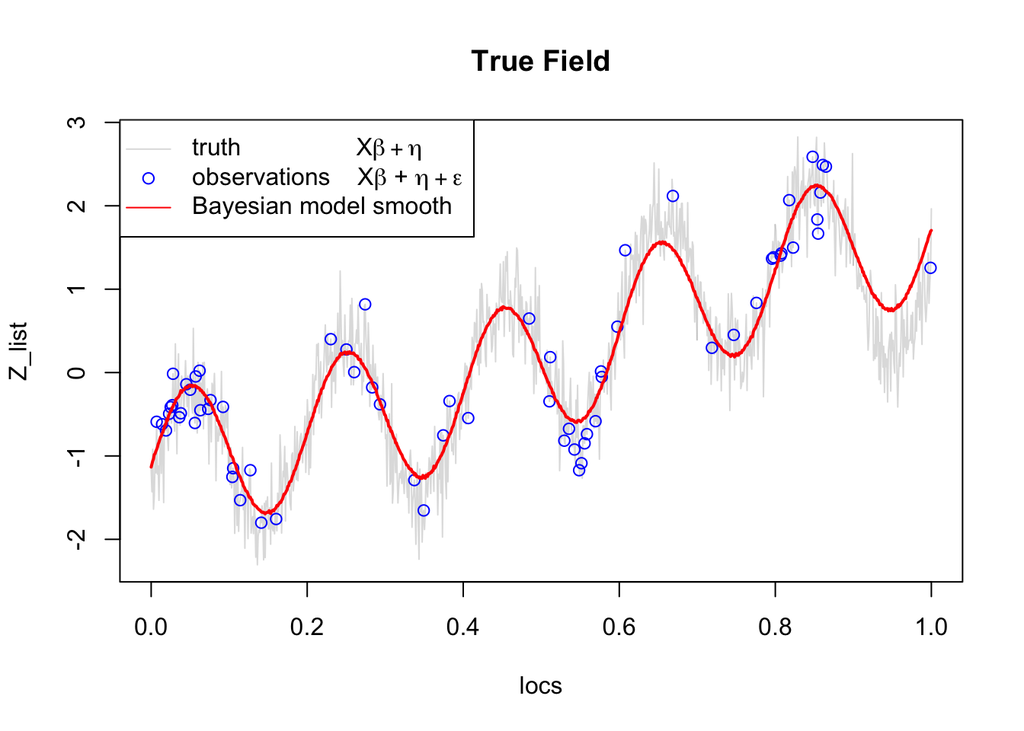

## Orthogonalization models (kernel convolution RSR)

[output not shown]

Examine the MCMC model predictions

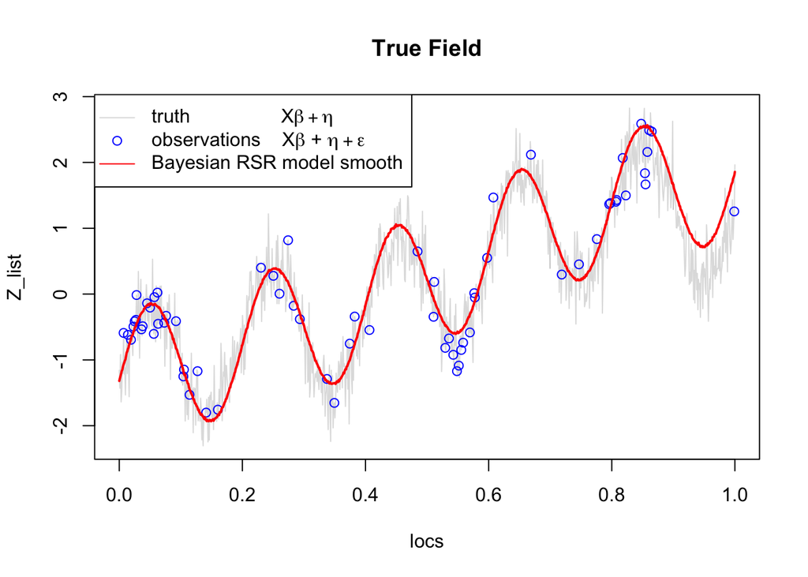

# Appendix

## Full conditionals for the complete pooling Bayesian Hierarchical Kernel convolution model

#### Full conditional for $\boldsymbol{\beta}$

$[\boldsymbol{\beta} | \cdot] \propto [\mathbf{y} | \boldsymbol{\beta}, \boldsymbol{\alpha}, \boldsymbol{\Sigma}_\epsilon] [\boldsymbol{\beta} | \boldsymbol{\mu_{\beta}},\boldsymbol{\Sigma}_{\beta}] \\ \propto \exp{ \{ - \frac{1} {2} (\mathbf{y} - \mathbf{X} \boldsymbol{\beta} - \mathbf{K} \boldsymbol{\alpha})' \boldsymbol{\Sigma}_{\epsilon}^{ - 1} (\mathbf{y} - \mathbf{X} \boldsymbol{\beta} - \mathbf{K} \boldsymbol{\alpha})\} } \exp{ \{ - \frac{1} {2} (\boldsymbol{\beta} - \boldsymbol{\mu_{\beta}})' {\Sigma}_{\beta}^{ - 1} (\boldsymbol{\beta} - \boldsymbol{\mu_{\beta}}) \} } \\ \propto \exp{ \{ - \frac{1} {2} [ \boldsymbol{\beta}' (\mathbf{X}' \boldsymbol{\Sigma}_{\epsilon}^{ - 1} \mathbf{X} - \boldsymbol{\Sigma}_{\beta}^{ - 1}) \boldsymbol{\beta} - 2 \boldsymbol{\beta}' (\mathbf{X}' \boldsymbol{\Sigma}_{\epsilon}^{ - 1} (\mathbf{y} - \mathbf{K} \boldsymbol{\alpha}) ] \} } \\$ which is N$(\mathbf{A}^{ - 1} \mathbf{b}, \mathbf{A}^{ - 1})$ where $\mathbf{A} = \mathbf{X}' \boldsymbol{\Sigma}_{\epsilon}^{ - 1} \mathbf{X} - \boldsymbol{\Sigma}_{\beta}^{ - 1} = \frac{\mathbf{X}'\mathbf{X}} {\sigma^2_\epsilon} - \frac{1} {\sigma^2_\beta} \mathbf {I} \\ \mathbf{b} = \mathbf{X}' \boldsymbol{\Sigma}_{\epsilon}^{ - 1} (\mathbf{y} - \mathbf{K} \boldsymbol{\alpha}) = \frac{\mathbf{X}' (\mathbf{y} - \mathbf{K} \boldsymbol{\alpha})} {\sigma^2_\epsilon} \\$

#### Full conditional for $\boldsymbol{\alpha}$

$[\boldsymbol{\alpha} | \cdot] \propto [\mathbf{y} | \boldsymbol{\beta}, \boldsymbol{\alpha}, \boldsymbol{\Sigma}_\epsilon] [\boldsymbol{\alpha} | \boldsymbol{\mu_{\alpha}},\boldsymbol{\Sigma}_{\alpha}] \\ \propto \exp{ \{ - \frac{1} {2} (\mathbf{y} - \mathbf{X} \boldsymbol{\beta} - \mathbf{K} \boldsymbol{\alpha})' \boldsymbol{\Sigma}_{\epsilon}^{ - 1} (\mathbf{y} - \mathbf{X} \boldsymbol{\beta} - \mathbf{K} \boldsymbol{\alpha})\} } \exp{ \{ - \frac{1} {2} (\boldsymbol{\alpha} - \boldsymbol{\mu_{\alpha}})' {\Sigma}_{\alpha}^{ - 1} (\boldsymbol{\alpha} - \boldsymbol{\mu_{\alpha}}) \} } \\ \propto \exp{ \{ - \frac{1} {2} [ \boldsymbol{\alpha}' (\mathbf{K}' \boldsymbol{\Sigma}_{\epsilon}^{ - 1} \mathbf{K} - \boldsymbol{\Sigma}_{\alpha}^{ - 1}) \boldsymbol{\alpha} - 2 \boldsymbol{\alpha}' (\mathbf{K}' \boldsymbol{\Sigma}_{\epsilon}^{ - 1} (\mathbf{y} - \mathbf{X} \boldsymbol{\beta}) ] \} } \\$ which is N$(\mathbf{A}^{ - 1} \mathbf{b}, \mathbf{A}^{ - 1})$ where $\mathbf{A} = \mathbf{K}' \boldsymbol{\Sigma}_{\epsilon}^{ - 1} \mathbf{K} - \boldsymbol{\Sigma}_{\alpha}^{ - 1} = \frac{\mathbf{K}'\mathbf{K}} {\sigma^2_\epsilon} - \frac{1} {\sigma^2_\alpha} \mathbf {I} \\ \mathbf{b} = \mathbf{K}' \boldsymbol{\Sigma}_{\epsilon}^{ - 1} (\mathbf{y} - \mathbf{X} \boldsymbol{\beta}) = \frac{\mathbf{K}' (\mathbf{y} - \mathbf{X} \boldsymbol{\beta})} {\sigma^2_\epsilon} \\$

#### Full conditional for $\sigma^2_{\epsilon}$

$[\sigma^2_{\epsilon} | \cdot] \propto [\mathbf{y} | \boldsymbol{\beta}, \boldsymbol{\alpha}, \boldsymbol{\Sigma}_\epsilon] [\sigma^2_{\epsilon}] \\ \propto |\boldsymbol{\Sigma}_{\epsilon}|^{ - \frac{1}{2}} \exp{ \{ - \frac{1} {2} (\mathbf{y} - \mathbf{X} \boldsymbol{\beta} - \mathbf{K} \boldsymbol{\alpha})' \boldsymbol{\Sigma}_{\epsilon}^{ - 1} (\mathbf{y} - \mathbf{X} \boldsymbol{\beta} - \mathbf{K} \boldsymbol{\alpha}) \} } {\sigma^2_{\epsilon}}^{ - \alpha_{\sigma^2_{\epsilon}} - 1} \exp{\{ - \frac{\beta_{\sigma^2_{\epsilon}}}{\sigma^2_\epsilon} \}} \\$ $\propto (\sigma^2_{\epsilon})^{ - \alpha_{\sigma^2_{\epsilon}} - \frac{p}{2} - 1} \exp{ \{ -\frac{1}{\sigma^2_{\epsilon}}[ \beta_{\sigma^2_{\epsilon}} + \frac{1} {2} (\mathbf{y} - \mathbf{X} \boldsymbol{\beta} - \mathbf{K} \boldsymbol{\alpha})' (\mathbf{y} - \mathbf{X} \boldsymbol{\beta} - \mathbf{K} \boldsymbol{\alpha}) ] \} } \\$ which is IG$(\alpha_{\sigma^2_{\epsilon}} + \frac{n} {2}, \beta_{\sigma^2_{\epsilon}} + \frac{1}{2}(\mathbf{y} - \mathbf{X} \boldsymbol{\beta} - \mathbf{K} \boldsymbol{\alpha})' (\mathbf{y} - \mathbf{X} \boldsymbol{\beta} - \mathbf{K} \boldsymbol{\alpha}) )$

#### Full conditional for $\sigma^2_{\beta}$

$[\sigma^2_{\beta} | \cdot] \propto [\boldsymbol{\beta} | \boldsymbol{\mu_{\beta}},\boldsymbol{\Sigma}_{\beta}] [\sigma^2_{\beta}] \\ \propto |\boldsymbol{\Sigma}_{\beta}|^{ - \frac{1}{2}} \exp{ \{ - \frac{1} {2} (\boldsymbol{\beta} - \boldsymbol{\mu_{\beta}})' \boldsymbol{\Sigma}_{\beta}^{ - 1} (\boldsymbol{\beta} - \boldsymbol{\mu_{\beta}}) \} } {\sigma^2_{\beta}}^{ - \alpha_{\sigma^2_{\beta}} - 1} \exp{\{ - \frac{\beta_{\sigma^2_{\beta}}}{\sigma^2_\beta} \}} \\$ $\propto (\sigma^2_{\beta})^{ - \alpha_{\sigma^2_{\beta}} - \frac{p}{2} - 1} \exp{ \{ -\frac{1}{\sigma^2_{\beta}}[ \beta_{\sigma^2_{\beta}} + \frac{1} {2} (\boldsymbol{\beta} - \boldsymbol{\mu_{\beta}})' (\boldsymbol{\beta} - \boldsymbol{\mu_{\beta}}) ] \} } \\$ which is IG$(\alpha_{\sigma^2_{\beta}} + \frac{p} {2}, \beta_{\sigma^2_{\beta}} + \frac{1}{2} (\boldsymbol{\beta} - \boldsymbol{\mu_{\beta}})' (\boldsymbol{\beta} - \boldsymbol{\mu_{\beta}}) )$

#### Full conditional for $\sigma^2_{\alpha}$

$[\sigma^2_{\alpha} | \cdot] \propto [\boldsymbol{\alpha} | \boldsymbol{\mu_{\alpha}},\boldsymbol{\Sigma}_{\alpha}] [\sigma^2_{\alpha}] \\ \propto |\boldsymbol{\Sigma}_{\alpha}|^{ - \frac{1}{2}} \exp{ \{ - \frac{1} {2} (\boldsymbol{\alpha} - \boldsymbol{\mu_{\alpha}})' \boldsymbol{\Sigma}_{\alpha}^{ - 1} (\boldsymbol{\alpha} - \boldsymbol{\mu_{\alpha}}) \} } {\sigma^2_{\alpha}}^{ - \alpha_{\sigma^2_{\alpha}} - 1} \exp{\{ - \frac{\beta_{\sigma^2_{\alpha}}}{\sigma^2_\alpha} \}} \\$ $\propto (\sigma^2_{\alpha})^{ - \alpha_{\sigma^2_{\alpha}} - \frac{p}{2} - 1} \exp{ \{ -\frac{1}{\sigma^2_{\alpha}}[ \beta_{\sigma^2_{\alpha}} + \frac{1} {2} (\boldsymbol{\alpha} - \boldsymbol{\mu_{\alpha}})' (\boldsymbol{\alpha} - \boldsymbol{\mu_{\alpha}}) ] \} } \\$ which is IG$(\alpha_{\sigma^2_{\alpha}} + \frac{p} {2}, \beta_{\sigma^2_{\alpha}} + \frac{1}{2} (\boldsymbol{\alpha} - \boldsymbol{\mu_{\alpha}})' (\boldsymbol{\alpha} - \boldsymbol{\mu_{\alpha}}) )$